# Text Mining Exploration: Practice Problem

Load the packages needed for this practice set of problems:

```r
library(tidyverse)   # for visualization and data transformation
library(tidytext)    # for tidy text mining
library(topicmodels) # for topic modeling with LDA
```

Read the dataset for this exercise:

```r
text_rei <- read_csv("https://github.com/reisanar/datasets/raw/master/fl_20_text.csv")
```

Take a look a random sample from the dataset:

```r
text_rei %>%
  sample_n(size = 10)
```

| due_date | comments |
| --- | --- |
| document_01 | Article ( ) |
| document_01 | Offensive Machine Learning Techniques: Neural networks were the commonly used technique, while unsupervised ML techniques such as association rule mining, frequent pattern mining, and clustering were … |
| document_03 | What did I enjoy about this presentation? |
| document_02 | I feel like this was my problem back in statistical learning, that the outputs should be somewhat "cookie-cutter" in a sense, which is what I was expecting, but this is most definitely not the case. |
| document_02 | Something I found interesting in this lecture was his comparisons of data analytics to other subjects. He showed how theories in music control what will sound good and what wont, so we use the same lo… |
| document_01 | I enjoyed the way she explained and differentiated support and confidence, in that support is based on the probability of both sets occurring together, while confidence is the probability that those i… |
| document_02 | I always look forward to new episodes of NSSDs, with rockstar Dr. Hilary Parker (former data scientist at @Etsy and @StitchFix ), and the Effort Report with legend Dr. Elizabeth Matsui (now @ UT Austi… |
| document_01 | After watching the presentation, I found it very interesting specifically the topic about Lyft and that Lyft is a really cool way to determine whether or not something is interesting through the inter… |
| document_03 | It’s neat how so many programming languages were born out of necessity instead of trying to reinvent the wheel. I didn’t realize it was developed as a mac alternative to a preexisting software. Some t… |
| document_02 | Dr. Peng's lecture was great to watch and very insightful. He provided many applications and examples to explain what data analysis is and how it works. His approach on the word research versus re-sea… |

# Tokenization and `tf-idf`

**Perform tokenization using TF-IDF**

Recall that: in [TF-IDF](https://en.wikipedia.org/wiki/Tf%E2%80%93idf) (term frequency – inverse document frequency)

- TF = frequency of term
- IDF = logarithm of inverse of the frequency with which documents have that term

More formally, for a given document $d$ and term $t$, the **Term Frequency** is the number of times term $t$ appears in document $d$ :

$$TF(d, t) = \text{# times }t \text{ appears in document }d$$

To account for terms that appear frequently in the domain of interest, we compute the **Inverse Document Frequency** of term $t$, calculated over the entire corpus and defined as

$$IDF(t) = \ln\left( \frac{\text{total number of documents}}{\text{# documents containing term } t} \right)$$

- TF-IDF is high where a rare term is present or frequent in a document
- TF-IDF is near zero where a term is absent from a document, or abundant across all documents

We can use the `tidytext::bind_tf_idf()` function to easily compute TFIDF for every term:

```r
rei_tf_idf <- text_rei %>%
  unnest_tokens(word, comments) %>% # remove stop words
  anti_join(stop_words) %>% # remove stop words
  count(due_date, word, sort = TRUE) %>%
  bind_tf_idf(word, due_date, n) %>%
  arrange(-tf_idf) %>%
  group_by(due_date) %>%
  top_n(20) %>%
  ungroup()
```

Explore:

```r
rei_tf_idf
```

| due_date | word | n | tf | idf | tf_idf |
| --- | --- | --- | --- | --- | --- |
| document_01 | rule | 53 | 0.025358852 | 1.0986123 | 0.027859546 |
| document_01 | association | 71 | 0.033971292 | 0.4054651 | 0.013774174 |
| document_01 | mining | 61 | 0.029186603 | 0.4054651 | 0.011834149 |
| document_02 | music | 47 | 0.024201854 | 0.4054651 | 0.009813007 |
| document_03 | source | 20 | 0.008888889 | 1.0986123 | 0.009765443 |
| document_01 | algorithm | 17 | 0.008133971 | 1.0986123 | 0.008936081 |
| document_03 | cran | 17 | 0.007555556 | 1.0986123 | 0.008300626 |
| document_03 | macintosh | 16 | 0.007111111 | 1.0986123 | 0.007812354 |
| document_03 | release | 16 | 0.007111111 | 1.0986123 | 0.007812354 |
| document_01 | apriori | 14 | 0.006698565 | 1.0986123 | 0.007359125 |

[output cut: 65 more lines]

Create a visualization showing the top TF-IDF scores in the text data for this exercise:

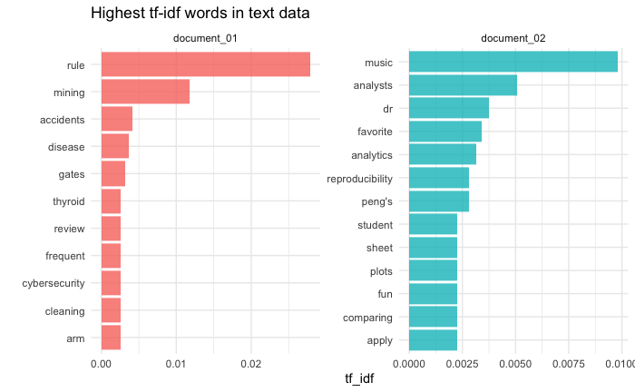

```r
text_plot <- rei_tf_idf %>%
  mutate(word = reorder(word, tf_idf)) %>%
  filter(str_detect(due_date, c("01", "02"))) %>%
  ggplot(aes(x = word, y = tf_idf, fill = due_date)) +
  geom_col(alpha = 0.8, show.legend = FALSE) +
  facet_wrap(~ due_date, scales = "free", ncol = 2) +
  coord_flip() +
  labs(x = "", "tf-idf", title = "Highest tf-idf words in text data") +
  theme_minimal()
text_plot
```

# Topic Modeling

We will use Latent Dirichlet Allocation (LDA) for topic modeling, using the `topicmodels` package.

Right now our data frame is in a tidy form, with **one-term-per-document-per-row**, but the `topicmodels` package requires a `DocumentTermMatrix`. We can *cast* a one-token-per-row table into a `DocumentTermMatrix` with `tidytext`’s function `cast_dtm()`. Additionally we remove any stop words.

```r
text_tidy <- text_rei %>%
  unnest_tokens(word, comments) %>%
  anti_join(stop_words)
```

Check:

```r
text_tidy
```

| due_date | word |
| --- | --- |
| document_01 | enjoyed |
| document_01 | explained |
| document_01 | differentiated |
| document_01 | support |
| document_01 | confidence |
| document_01 | support |
| document_01 | based |
| document_01 | probability |
| document_01 | sets |
| document_01 | occurring |

[output cut: 990 more lines]

Use `cast_dtm()`:

```r
text_dtm <- text_tidy %>%
  count(due_date, word, sort = TRUE) %>%
  cast_dtm(due_date, word, n)
```

Apply LDA:

```r
text_lda <- LDA(text_dtm, k = 3, control = list(seed = 3513))
text_lda
```

```
A LDA_VEM topic model with 3 topics.
```

Extract the `beta`s (word-topic probabilities)

```r
text_topics <- tidy(text_lda, matrix = "beta")

text_topics
```

| topic | term | beta |
| --- | --- | --- |
| 1 | data | 7.826982e-02 |
| 2 | data | 8.000000e-03 |
| 3 | data | 2.105263e-02 |
| 1 | analysis | 3.759011e-02 |
| 2 | analysis | 3.555556e-03 |
| 3 | analysis | 5.741627e-03 |
| 1 | association | 5.149331e-04 |
| 2 | association | 6.628196e-36 |
| 3 | association | 3.397129e-02 |
| 1 | mining | 5.149331e-04 |

[output cut: 990 more lines]

Notice that this has turned the model into a one-topic-per-term-per-row format. For each combination, the model computes the *probability of that term being generated from that topic*.

We could use `dplyr`’s `top_n()` to find the top 10 terms within each topic:

```r
top_terms <- text_topics %>%
  group_by(topic) %>%
  top_n(10, beta) %>%
  ungroup() %>%
  arrange(topic, -beta)

top_terms
```

| topic | term | beta |
| --- | --- | --- |
| 1 | data | 0.078269825 |
| 1 | analysis | 0.037590113 |
| 1 | music | 0.024201854 |
| 1 | theory | 0.014418126 |
| 1 | lecture | 0.009783728 |
| 1 | rules | 0.009783728 |
| 1 | dr | 0.009268795 |
| 1 | science | 0.008238929 |
| 1 | found | 0.008238929 |
| 1 | enjoyed | 0.007723996 |

[output cut: 20 more lines]

Create a chart showing the highest word probabilities for each topic:

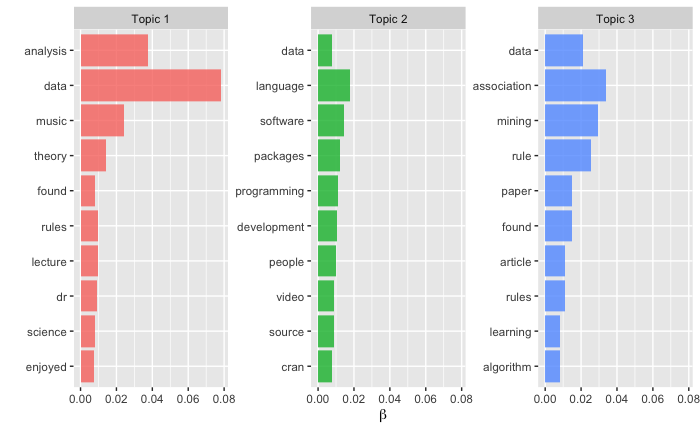

```r
graph_topics <- top_terms %>%
  mutate(topic = paste0("Topic ", topic),
         term = reorder(term, beta)) %>%
  ggplot(aes(x = term, y = beta, fill = factor(topic))) +
  geom_col(alpha = 0.8, show.legend = FALSE) +
  facet_wrap(~topic, scales = "free_y") +
  coord_flip() +
  labs(x = "", y = expression(beta))

graph_topics
```

## Network of bigrams

Next, we create a bigram network. First, perform tokenization and remove stop-words:

```r
text_filtered <- text_rei %>%
  unnest_tokens(bigram, comments, token = "ngrams", n = 2) %>%
  separate(bigram, into = c("word1", "word2"), sep = " ") %>%
  filter(!word1 %in% stop_words$word) %>%
  filter(!word2 %in% stop_words$word)
```

We then find the most common combination of words:

```r
text_counts <- text_filtered %>%
  count(word1, word2, sort = TRUE)
```

Print the most frequent bigrams:

```r
# original counts
text_counts %>%
  filter(n > 2)
```

| word1 | word2 | n |
| --- | --- | --- |
| data | analysis | 69 |
| association | rule | 51 |
| rule | mining | 48 |
| data | science | 22 |
| programming | language | 16 |
| association | rules | 15 |
| data | analytics | 15 |
| machine | learning | 12 |
| music | theory | 12 |
| apriori | algorithm | 9 |

[output cut: 49 more lines]

Load the packages needed for graph visualization:

```r
library(igraph)
library(ggraph)
```

Build graph from data frame using the `graph_from_data_frame()` function:

```r
# filter for only relatively common combinations
bigram_graph <- text_counts %>%
  filter(n > 2) %>%
  graph_from_data_frame()

bigram_graph
```

```
IGRAPH 74c4cad DN-- 84 59 --
+ attr: name (v/c), n (e/n)
+ edges from 74c4cad (vertex names):
 [1] data            ->analysis    association     ->rule        rule            ->mining
 [4] data            ->science     programming     ->language    association     ->rules
 [7] data            ->analytics   machine         ->learning    music           ->theory
[10] apriori         ->algorithm   data            ->analysts    research        ->paper
[13] rules           ->mining      dr              ->peng        revolution      ->analytics
[16] transaction     ->data        data            ->mining      data            ->sets
[19] david           ->smith       dr              ->gates       source          ->software
[22] thyroid         ->disease     1.0             ->release     bus             ->stop
+ ... omitted several edges
```

Create plot:

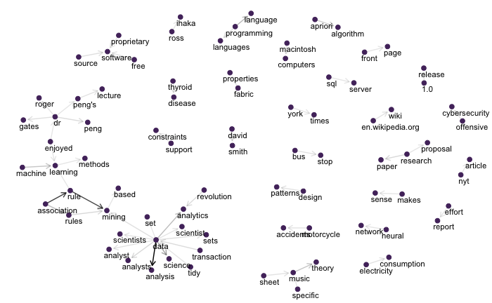

```r
set.seed(217)

# plot graph
bigrams_network <- ggraph(bigram_graph, layout = "fr") +
  geom_edge_link(
    aes(edge_alpha = n),
    show.legend = FALSE,
    end_cap = circle(.07, 'inches'),
    arrow = arrow(length = unit(2, "mm"))) +
  geom_node_point(color = "#53316B",
                  size = 2) +
  geom_node_text(aes(label = name),
                 vjust = 1.5, hjust = 0.2, size = 3) +
  theme_void()

bigrams_network
```